# Lecture 8: Hypothesis Testing: Z-score and Chi-Square

Tom Hanna

tlhanna@central.uh.edu

University of Houston

2026-04-18

# Agenda and Announcements

- Today

  ```
    - Hypothesis Testing: Z-Score and Chi-Square
    - Top Hat Quiz
  ```

- Next class

  ```
    - Lab 4 completion
    - Lab 5
  ```

# Hypothesis testing Z-Scores

## What is a Z-Score?

- A z-score tells us how many standard deviations a value is from the mean.
- Positive z-scores are above the mean
- Negative z-scores are below the mean
- A z-score is the **precise** representation of the 68-95-99 Rule

## The tails

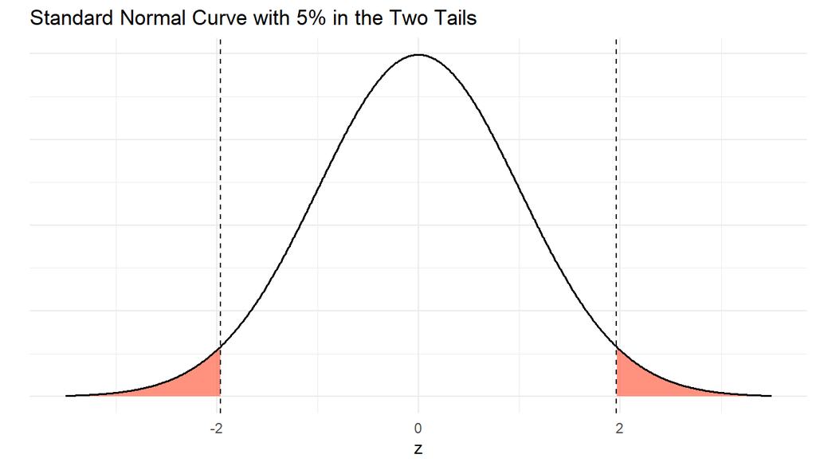

## Two-tail test

- In a hypothesis test, we are testing the probability that the event is not due to random chance
- We set a threshold (usually α = 0.05) for how unlikely a result must be before we reject the null hypothesis
- In a two-tail test, we split α into both tails: α/2 = 0.025 in each tail
- If our test statistic falls in either tail (beyond ±1.96), we reject the null hypothesis
- This corresponds to a probability less than 5% or p < .05

## Z-Test: Formula

**Formula:**

$$z = \frac{\bar{x} - \mu_0}{\sigma / \sqrt{n}}$$

**Where:**

- $\bar{x}$ = sample mean
- $\mu_0$ = hypothesized population mean (from null hypothesis)
- $\sigma$ = population standard deviation
- $n$ = sample size

## Z-Test: Steps

**Steps:**

1. State your null hypothesis ($H_0: \mu = \mu_0$) and alternative hypothesis ($H_a$)
2. Calculate the test statistic using the formula above
3. For a two-tail test at $\alpha = 0.05$, the critical values are $z = \pm 1.96$

## Z-test: Decision rule

Two tail:

- **Reject** $H_0$ if $z > 1.96$ or $z < -1.96$
- **Fail to reject** $H_0$ if $-1.96 \le z \le 1.96$
- Shorthand: reject if $|z| > 1.96$

## Z-tail: Right tail decision rule

**Right-tail test** ($H_a: \mu > \mu_0$)

- Critical value: $z_{critical} = 1.645$
- Decision rule:
  - **Reject** $H_0$ if $z > 1.645$
  - **Fail to reject** $H_0$ if $z \le 1.645$
  - Shorthand: reject if $z$ is in the **right tail** beyond 1.645

## Z-tail: Left-tail decision rule

**Left-tail test** ($H_a: \mu < \mu_0$)

- Critical value: $z_{critical} = -1.645$
- Decision rule:
  - **Reject** $H_0$ if $z < -1.645$
  - **Fail to reject** $H_0$ if $z \ge -1.645$
  - Shorthand: reject if $z$ is in the **left tail** beyond -1.645

## What is a Crosstab?

- A **crosstab** (contingency table) shows counts for two categorical variables in rows and columns
- Each cell contains the **frequency** of cases with that combination of categories

## Example Crosstab

**Example structure (2×3 table):**

|  | Category 1 | Category 2 | Category 3 |
| --- | --- | --- | --- |
| Group A | ? | ? | ? |
| Group B | ? | ? | ? |

## Example: Observed Counts Only

**Research Question:** Is there an association between gender and support for a new campus policy?

**Observed data from 200 students:**

|  | Support | Oppose |
| --- | --- | --- |
| **Female** | 60 | 40 |
| **Male** | 45 | 55 |

## Example: Add Row and Column Totals

**Fill in the marginals (row totals, column totals, and grand total):**

|  | Support | Oppose | Row Total |
| --- | --- | --- | --- |
| **Female** | 60 | 40 | ___ |
| **Male** | 45 | 55 | ___ |
| **Column Total** | ___ | ___ | **___** |

## Example: Completed Observed Table

|  | Support | Oppose | Row Total |
| --- | --- | --- | --- |
| **Female** | 60 | 40 | 100 |
| **Male** | 45 | 55 | 100 |
| **Column Total** | 105 | 95 | **200** |

## Example: Calculate Expected Counts

**Formula:** $E_{ij} = \frac{(\text{row total}) \times (\text{column total})}{\text{grand total}}$

**Calculate expected count for each cell:**

- Female & Support: $E_{11} = \frac{100 \times 105}{200} = \_\_\_$
- Female & Oppose: $E_{12} = \frac{100 \times 95}{200} = \_\_\_$
- Male & Support: $E_{21} = \frac{100 \times 105}{200} = \_\_\_$
- Male & Oppose: $E_{22} = \frac{100 \times 95}{200} = \_\_\_$

## Example: Expected Counts Table

|  | Support | Oppose | Row Total |
| --- | --- | --- | --- |
| **Female** | 52.5 | 47.5 | 100 |
| **Male** | 52.5 | 47.5 | 100 |
| **Column Total** | 105 | 95 | **200** |

**These are the counts we would expect if there were NO association**

## Example: Calculate (O - E) for Each Cell

**For each cell, compute:** Observed - Expected

|  | Support | Oppose |
| --- | --- | --- |
| **Female** | 60 - 52.5 = ___ | 40 - 47.5 = ___ |
| **Male** | 45 - 52.5 = ___ | 55 - 47.5 = ___ |

## Example: Differences (O - E)

|  | Support | Oppose |
| --- | --- | --- |
| **Female** | +7.5 | -7.5 |
| **Male** | -7.5 | +7.5 |

**Note the symmetry:** Differences sum to zero in each row and column

## Where did we run into this before?

- Variance
- When we talked about computing confidence intervals, squaring deviations meant we couldn’t use the normal distribution
- That meant we couldn’t use a z-score there
- What distribution did we have to use?

## Distribution Comparison

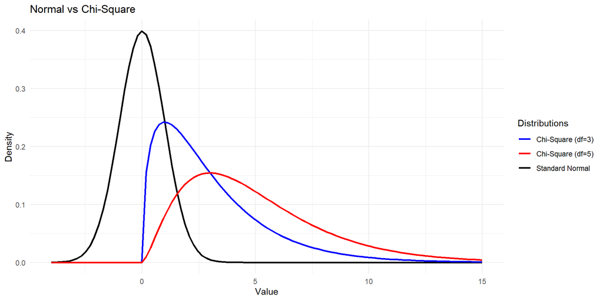

## χ² instead of z-score

- Here we will use the **χ²** statistic instead of the z-score
- The z-score is always based on the **same** normal distribution
- The chi-square is not just one curve: we pick a specific **χ² distribution** based on the degrees of freedom

## What is degrees of freedom?

- Chi-square shows up whenever we add up **squared differences between what we observe and what we expect**
- These are also called **squared residuals**
- The **degrees of freedom** tell us how many **independent pieces** of information went into that total
- In a crosstab, fixing the row and column totals means not every cell can vary freely, so the df is $(r - 1)(c - 1)$
- So instead of one universal z table, we have a family of χ² tables—one curve for each degrees-of-freedom value.

## χ² Critical Values (α = 0.05)

| df | χ² critical (α = 0.05) |
| --- | --- |
| 1 | 3.84 |
| 2 | 5.99 |
| 3 | 7.82 |
| 4 | 9.49 |
| 5 | 11.07 |
| 6 | 12.59 |

## Example: next step

**Calculate $\frac{(O - E)^2}{E}$ for Each Cell**

$$\chi^2 = \sum \frac{(O - E)^2}{E}$$

**Female & Support:** $\frac{(7.5)^2}{52.5} = \frac{56.25}{52.5} = \_\_\_$

**Female & Oppose:** $\frac{(-7.5)^2}{47.5} = \frac{56.25}{47.5} = \_\_\_$

**Male & Support:** $\frac{(-7.5)^2}{52.5} = \frac{56.25}{52.5} = \_\_\_$

**Male & Oppose:** $\frac{(7.5)^2}{47.5} = \frac{56.25}{47.5} = \_\_\_$

## Example: Chi-Square Components

**Female & Support:** $\frac{56.25}{52.5} = 1.071$

**Female & Oppose:** $\frac{56.25}{47.5} = 1.184$

**Male & Support:** $\frac{56.25}{52.5} = 1.071$

**Male & Oppose:** $\frac{56.25}{47.5} = 1.184$

**Sum all four:** $\chi^2 = 1.071 + 1.184 + 1.071 + 1.184 = \_\_\_$

## Example: Chi-Square Test Statistic

$$\chi^2_{calc} = 4.51$$

**Now we need to compare this to the critical value**

## Example: Find Degrees of Freedom

$$df = (r - 1)(c - 1)$$

- Number of rows: $r = \_\_\_$
- Number of columns: $c = \_\_\_$

$$df = (\_\_\_ - 1)(\_\_\_ - 1) = \_\_\_$$

## Example: Degrees of Freedom

$$df = (r - 1)(c - 1)$$

- Number of rows: $r = 2$
- Number of columns: $c = 2$

$$df = (2 - 1)(2 - 1) = 1$$

## Example: Critical Value

**From chi-square distribution table:**

- $df = 1$
- $\alpha = 0.05$
- $\chi^2_{critical} = 3.841$

## Example: Make Decision

**Decision rule:** Reject $H_0$ if $\chi^2_{calc} > \chi^2_{critical}$

**Our values:** - $\chi^2_{calc} = 4.51$ - $\chi^2_{critical} = 3.841$

**Decision:** _______________

## Example: Conclusion

**Since $4.51 > 3.841$, we REJECT $H_0$**

**Conclusion:** - There **is** a statistically significant association between gender and support for the policy - The pattern in our sample is unlikely to be due to chance alone - Females show higher support (60%) than males (45%)

## Berkeley Graduate Admissions 1973

**Did America’s most progressive graduate school discriminate on gender in admissions?**

```
, , Dept = A

          Gender
Admit      Male Female
  Admitted  512     89
  Rejected  313     19

, , Dept = B

          Gender
Admit      Male Female
  Admitted  353     17
  Rejected  207      8

, , Dept = C

          Gender
Admit      Male Female
  Admitted  120    202
  Rejected  205    391

, , Dept = D

          Gender
Admit      Male Female
  Admitted  138    131
  Rejected  279    244

, , Dept = E

          Gender
Admit      Male Female
  Admitted   53     94
  Rejected  138    299

, , Dept = F

          Gender
Admit      Male Female
  Admitted   22     24
  Rejected  351    317
```

```
                Dept   A   B   C   D   E   F
Admit    Gender
Admitted Male        512 353 120 138  53  22
         Female       89  17 202 131  94  24
Rejected Male        313 207 205 279 138 351
         Female       19   8 391 244 299 317
```

## 1973 Berkeley Example Data (Overall)

**Overall admissions (all departments combined)**

|  | Admitted | Rejected | Total |
| --- | --- | --- | --- |
| **Male** | 44 | 56 | 100 |
| **Female** | 30 | 70 | 100 |
| **Total** | 74 | 126 | 200 |

## 1973 Berkeley Example Data (By Department)

**Admissions by department (simplified)**

| Dept | Gender | Admitted | Rejected | Total |
| --- | --- | --- | --- | --- |
| A | Male | 40 | 60 | 100 |
|  | Female | 45 | 55 | 100 |
| B | Male | 30 | 70 | 100 |
|  | Female | 36 | 64 | 100 |
| C | Male | 30 | 70 | 100 |
|  | Female | 15 | 85 | 100 |

## For this week’s quiz points (25 points)

- Complete the crosstabs hypothesis test for the table with admissions by department. (That is a single test with 6 rows by 2 columns)
- Do a crosstab for each department. (That is 3 tests with 2 rows by 2 rows)
- Do this by hand and give your conclusions.
- More on the next slide

## Part 2

- Bring this to class Thursday or turn it in my mailbox in the Political Science Department office (PGH 447)
- Mostly completion - if you make errors, we will discuss
- Read these and answer three questions in Canvas “March 23-26 Quiz”

  ```
    - https://setosa.io/simpsons/
    - https://statisticsbyjim.com/basics/simpsons-paradox/
  ```

- We will revisit using R in lab on Thursday!
- I will post Thursday lab Monday or Tuesday evening with recording

## Authorship and License

- Author: Tom Hanna
- Website: [tomhanna.me](https://tom-hanna.org/)
- License: This work is licensed under a [Creative Commons Attribution-NonCommercial-ShareAlike 4.0 International License.</>](http://creativecommons.org/licenses/by-nc-sa/4.0/)